# Regularization and Sparse Models

Steve Elston

11/07/2023

# Review

There are a number of assumptions in linear models that you overlook at your peril!

- The feature or predictor variables should be **independent** of one another
  - This is rarely true in practice
  - **Multi-collinearity** between features makes the model **under-determined**
- We assume that numeric features or predictors have **zero mean** and about the **same scale**
  - Do not want to bias the estimation of regression coefficients with predictors that do not have a 0 mean
  - Do not want to have predictors with a large numeric range dominate training
- Values of each predictor or feature should be iid
  - If variance changes with sample, the optimal value of the coefficient is not constant
  - If there **serial correlation** in the predictor values, the iid assumption is violated - use time series models

# Review

Representation of machine learning models

- The key representation is the model matrix
  - Column of 1s for intercept
  - Columns of feature or predictor values

$$A =
\begin{bmatrix}
1, x_{1,1}, x_{1,2}, \ldots, x_{1,p}\\
1, x_{2,1}, x_{2,2}, \ldots, x_{2,p}\\
1, x_{3,1}, x_{3,2}, \ldots, x_{3,p}\\
\vdots,\ \vdots,\ \vdots,\ \vdots,\ \vdots\\
1, x_{n,1}, x_{n,2}, \ldots, x_{n,p}
\end{bmatrix}$$

- There are two standards for signatures of ML functions
  - A model matrix $X$ (exogenous-features) and label array $Y$ (dependent-endogenous) - Scikit-learn and base Statsmodels
  - A data frame with all features (predictors) and label (dependent) columns plus a model formula - Statsmodels formula and R

# Review

- Models with nonlinear response have non-Normal distributions
- The generalized linear model accommodates nonlinear response distributions
- Link function transforms to linear model
  - Inverse link function transforms from Normal distribution to response distribution
- Evaluating Binomial response models
  - Confusion matrix organizes
  - Compute metrics from elements of confusion matrix
  - Use multiple evaluation criteria
- Compare model performance with deviance

# Dealing with Overfit Models

Example: We suspect that the terms, ses and prog are significant in predicting social science test scores:

```python
formula = 'socst ~ C(ses)*C(prog)'
#linear_model = smf.ols("socst ~ C(ses)*C(prog)", data=test_scores_train).fit()
linear_model = smf.ols(formula, data=test_scores_train).fit()
linear_model.summary()
```

OLS Regression Results

| Dep. Variable: | socst | R-squared: | 0.348 |
| --- | --- | --- | --- |
| Model: | OLS | Adj. R-squared: | 0.309 |
| Method: | Least Squares | F-statistic: | 8.753 |
| Date: | Mon, 06 Nov 2023 | Prob (F-statistic): | 1.55e-09 |
| Time: | 17:42:57 | Log-Likelihood: | -495.01 |
| No. Observations: | 140 | AIC: | 1008. |
| Df Residuals: | 131 | BIC: | 1035. |
| Df Model: | 8 |  |  |
| Covariance Type: | nonrobust |  |  |

|  | coef | std err | t | P>\|t\| | [0.025 | 0.975] |
| --- | --- | --- | --- | --- | --- | --- |
| Intercept | 46.1667 | 2.478 | 18.627 | 0.000 | 41.264 | 51.070 |
| C(ses)[T.2] | 3.7564 | 3.437 | 1.093 | 0.276 | -3.043 | 10.556 |
| C(ses)[T.3] | 10.3333 | 4.293 | 2.407 | 0.017 | 1.841 | 18.826 |
| C(prog)[T.2] | 6.0476 | 3.378 | 1.791 | 0.076 | -0.634 | 12.729 |
| C(prog)[T.3] | -10.2917 | 3.919 | -2.626 | 0.010 | -18.044 | -2.539 |
| C(ses)[T.2]:C(prog)[T.2] | -0.8457 | 4.402 | -0.192 | 0.848 | -9.555 | 7.863 |
| C(ses)[T.3]:C(prog)[T.2] | -2.5476 | 5.114 | -0.498 | 0.619 | -12.664 | 7.569 |
| C(ses)[T.2]:C(prog)[T.3] | 9.2257 | 4.954 | 1.862 | 0.065 | -0.573 | 19.025 |
| C(ses)[T.3]:C(prog)[T.3] | 1.2917 | 6.788 | 0.190 | 0.849 | -12.136 | 14.719 |

| Omnibus: | 10.190 | Durbin-Watson: | 2.059 |
| --- | --- | --- | --- |
| Prob(Omnibus): | 0.006 | Jarque-Bera (JB): | 10.371 |
| Skew: | -0.651 | Prob(JB): | 0.00560 |
| Kurtosis: | 3.290 | Cond. No. | 18.7 |

Notes:  
[1] Standard Errors assume that the covariance matrix of the errors is correctly specified.

# Dealing with Overfit Models

Example: After 3 or 4 rounds of *guess and cut* feature pruning, we arrive at a model with only significant coefficients:

```python
linear_model = smf.ols("socst ~ - 1 + C(ses):C(prog)", data=test_scores_train).fit()
linear_model.summary()
```

OLS Regression Results

| Dep. Variable: | socst | R-squared: | 0.348 |
| --- | --- | --- | --- |
| Model: | OLS | Adj. R-squared: | 0.309 |
| Method: | Least Squares | F-statistic: | 8.753 |
| Date: | Mon, 06 Nov 2023 | Prob (F-statistic): | 1.55e-09 |
| Time: | 17:42:57 | Log-Likelihood: | -495.01 |
| No. Observations: | 140 | AIC: | 1008. |
| Df Residuals: | 131 | BIC: | 1035. |
| Df Model: | 8 |  |  |
| Covariance Type: | nonrobust |  |  |

|  | coef | std err | t | P>\|t\| | [0.025 | 0.975] |
| --- | --- | --- | --- | --- | --- | --- |
| C(ses)[1]:C(prog)[1] | 46.1667 | 2.478 | 18.627 | 0.000 | 41.264 | 51.070 |
| C(ses)[2]:C(prog)[1] | 49.9231 | 2.381 | 20.965 | 0.000 | 45.212 | 54.634 |
| C(ses)[3]:C(prog)[1] | 56.5000 | 3.505 | 16.120 | 0.000 | 49.566 | 63.434 |
| C(ses)[1]:C(prog)[2] | 52.2143 | 2.295 | 22.755 | 0.000 | 47.675 | 56.754 |
| C(ses)[2]:C(prog)[2] | 55.1250 | 1.518 | 36.320 | 0.000 | 52.123 | 58.127 |
| C(ses)[3]:C(prog)[2] | 60.0000 | 1.568 | 38.277 | 0.000 | 56.899 | 63.101 |
| C(ses)[1]:C(prog)[3] | 35.8750 | 3.035 | 11.819 | 0.000 | 29.870 | 41.880 |
| C(ses)[2]:C(prog)[3] | 48.8571 | 1.874 | 26.077 | 0.000 | 45.151 | 52.563 |
| C(ses)[3]:C(prog)[3] | 47.5000 | 4.293 | 11.065 | 0.000 | 39.008 | 55.992 |

| Omnibus: | 10.190 | Durbin-Watson: | 2.059 |
| --- | --- | --- | --- |
| Prob(Omnibus): | 0.006 | Jarque-Bera (JB): | 10.371 |
| Skew: | -0.651 | Prob(JB): | 0.00560 |
| Kurtosis: | 3.290 | Cond. No. | 2.83 |

Notes:  
[1] Standard Errors assume that the covariance matrix of the errors is correctly specified.

# Dealing with Overfit Models

Let’s compare the results of the unpruned and pruned models

- The metrics indicate the fit is exactly the same
- Why prefer the sparse (pruned) model?
- What are the consequences of the over-fit model?
  - Several predictors (features) are included that are not needed
  - Including non-significant predictors can only increase noise and reduce generalization of a model
  - Colinear features confound model fiting - change of coefficient values correlated
  - For model with linear response, consider the effect of an unexpected value of a non-significant predictor
- But manually pruning a model with a great many features is a doomed task!
  - What if we included all the interactions with type of school, race and sex?
  - We now have up to 5th order interaction - 45 model coefficients with none significant!!

# Dealing with Overfit Models

We want our models to be **sparse**

- A sparse model has the minimum complexity required to explain the data
- The sparse model is a manifestation of **Occam’s Razor**
  - A scientific principle that the simplest of competing theories is the preferred one
- Sparse models use the minimum number of independent variables (features)
  - Are considered **parsimonious**
  - Generalize well
- Use regularization methods to identify minimum coefficient set

# Dealing with Overfit Models

**Idea!:** Try systematically pruning the model using some metric

- Leads to the the **step-wise regression algorithm**
  - Forward step-wise regression adds most explanatory variable one at a time
  - Backward step-wise regression removes least explanatory variable one at a time
  - Can go both directions - see the R documentation
  - Hard to find a good metric
- But, making multiple hypothesis tests is a fraught undertaking
  - $H_0$ is null or insignificant predictor
  - High probability of Type 1 or Type 2 error
  - Type 1 error, fail to accept $H_0$, $\rightarrow$ include insignificant predictor
  - Type 2 error, fail to reject $H_0$, $\rightarrow$ drop significant predictor

# Regularization - The Bias-Variance Trade-Off

Regularization is a systematic approach to preventing over-fitting

- To understand regularization need to understand the bias-variance trade-off
- To better understand this trade-off decompose mean square error:

$$\Delta Y^2 = \mathbb{E} \Big[ \big( Y -
\hat{f}(X) \big)^2 \Big]$$
$Y =$ the label vector
$X =$ the feature matrix
$\hat{f}(X) = \hat{Y}$ estimate from fitted model

Expanding this relation gives us:

$$\begin{align}
\Delta Y^2 &= \Big( \mathbb{E} [ \hat{f}(X)] - \hat{f}(X) \Big)^2 +
\mathbb{E} \Big[ \big( \hat{f}(X) - \mathbb{E} [ \hat{f}(X)] \big)^2
\Big] + \sigma^2\\
&= Bias^2 + Variance + Irreducible\ Error
\end{align}$$

# Regularization - The Bias-Variance Trade-Off

How do we interpret the bias-variance trade-off relationship:
$$\Delta Y^2 = \Big( \mathbb{E} [ \hat{f}(X)]
- \hat{f}(X) \Big)^2 + \mathbb{E} \Big[ \big( \hat{f}(X) - \mathbb{E}[
\hat{f}(X)] \big)^2 \Big] + \sigma^2$$
- $\mathbb{E} \Big[ \big( \hat{f}(X) - \mathbb{E} [ \hat{f}(X)] \big)^2 \Big]$, the expected squared difference between the model output and the expected model output is the **variance** of the model
- For low variance model, $\mathbb{E} \Big[ \big( \hat{f}(X) - \mathbb{E} [ \hat{f}(X)] \big)^2 \Big] \rightarrow 0$
- Model **generalizes** since variance is low for each prediction, $\hat{f}(X)$

- $\Big( \mathbb{E}[ \hat{f}(X)] - \hat{f}(X) \Big)^2$, the expected value of the difference between the model output and the expected model output is the **bias** of the model
  - For **unbiased model**, $\mathbb{E}\Big[ \hat{f}(X)] - \hat{f}(X) \Big] = 0$
  - Example: OLS model with $residuals \sim N(0, \sigma^2)$ is **unbiased**
- $\sigma^2$ is inherent or irreducable error in data

# Regularization - The Bias-Variance Trade-Off

There is a trade-off between bias and variance

- Need to find the optimal trade-off point

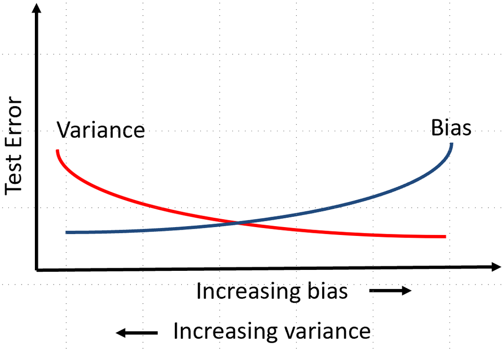

The trade-off between bias and variance

# Eigendecomposition - Review

For OLS model need to find $\big(A^TA \big)^{-1}A \propto Cov(A)^{-1}A$ for $p \times p$ design matrix $A$

- Decompose the $p \times p$ covariance matrix $cov(A) = \frac{1}{p}A^TA$ into **eigenvalues** and **eigenvectors**:

$$cov(A) = Q \Lambda Q^{-1}$$

- $Q$ is the $p \times p$ matrix of $p$ **orthonormal eigenvectors**
- For real-valued $cov(A)$ the eigenvectors $Q$ are real valued so:

$$Q^{-1} = Q^T$$

# Eigendecomposition - Review

Decompose the $p \times p$ covariance matrix $cov(A) = \frac{1}{p}A^TA$ into **eigenvalues** and **eigenvectors**:

$$cov(A) = Q \Lambda Q^{-1}$$

And, the $p$ eigenvalues are represented as diagonal matrix:

$$\Lambda =
\begin{bmatrix}
\lambda_1, 0, \ldots, 0\\
0, \lambda_2, \ldots, 0 \\
\vdots,\ \vdots,\ \ddots,\ \vdots\\
0, 0, \ldots, \lambda_{p}
\end{bmatrix}$$

# Eigendecomposition - Review

The inverse of the covariance can be computed from its eigendecomposition

$$cov(A)^{-1} = Q^T \Lambda^{-1}
Q$$

Where $\Lambda^{-1}$ is:

$$\Lambda^{-1} =
\begin{bmatrix}
\frac{1}{\lambda_1}, 0, \ldots, 0\\
0, \frac{1}{\lambda_2}, \ldots, 0 \\
\vdots,\ \vdots,\ \ddots,\ \vdots\\
0, 0, \ldots, \frac{1}{\lambda_p}
\end{bmatrix}$$

# Eigendecomposition - Review

At first look eigen-decomposition seems a bit mysterious

- The eigenvalues are the **roots** of the covariance matrix
  - Similar to the familiar roots of a polynomial
- For square matrix, $A$, and some Euclidean norm 1 vector, $x$, we can find a root, $\lambda$:

$$\begin{align}
Ax &= \lambda x \\
Ax - \lambda x &= 0 \\
(A - I \lambda) x &= 0
\end{align}$$

- For $p \times p$ dimensional matrix there are $p$ eigenvalues and orthogonal eigenvectors
- But, there is no guarantee that the $p$ values of $\lambda$ are unique
  - If columns of $A$ are colinear, there are $< p$ unique eigenvalues
  - With colinear independent variables some $\lambda_i \approx 0$

# Regularization - Ill-Posed Problems

If columns of $A$ are not linearly independent, the inverse of the covariance matrix is **ill-posed**

$$cov(A) = Q \Lambda Q^T\\
cov(A)^{-1} = Q^T \Lambda^{-1} Q$$

- The eigenvalues are ordered, $\lambda_1 \ge \lambda_2 \ge \ldots \ge \lambda_p$
- For **ill-posed** covariance matrix
  - The smallest $\lambda_i \rightarrow 0$
  - So, $\frac{1}{\lambda_i} \rightarrow \infty$
- Uh oh! The inverse covariance matrix **does not exist!**
  - With colinear features $\lambda_i \rightarrow 0\ \rightarrow$ confounded fitting
  - With unifromative features $\lambda_i \rightarrow 0\ \rightarrow$ projecting random noise

# L2 Regularization

L2 regularization constrains the Euclidean norm of the parameter vector, $\vec{b}$

- Recall:

$$x = A b + \epsilon$$

- The **normal equations provide a solution**:

$$b = (A^TA)^{-1}A^Tx$$

- This solution requires finding the inverse of the covariance matrix, $(A^TA)^{-1}$
  - But this inverse may be unstable since $\lambda_p \approx 0$
  - In mathematical terminology we say the problem is **ill-posed**

# L2 Regularization

L2 regularization constrains the Euclidean norm of the parameter vector, $\vec{b}$

- We can add a **bias term** to the diagonal of the covariance matrix

the **L2 or Euclidean norm** minimization problem):

$$min [\parallel A \cdot x - b \parallel
+\ \alpha^2 \parallel b\parallel]\\ or \\
b = (A^TA + \alpha^2 I)^{-1}A^Tx$$

Where the L2 norm of the coefficient vector is:
$$||b|| = \big( \beta_0^2 + \beta_1^2 + \ldots +
\beta_p^2 \big)^{\frac{1}{2}} = \Big( \sum_{i=0}^p \beta_i^2
\Big)^{\frac{1}{2}}$$

# L2 Regularization

How can we understand this relationship?

$$b = (A^TA +
\alpha^2I)^{-1}A^Tx$$

- Adds values along the diagonal of the covariance matrix
  - This creates a so called **ridge** in the covariance, $cov_{regularized} = A^TA + \alpha^2$
  - Leads to the term **ridge regression**
- Constrain the L2 norm values of the model coefficients using the **penalty term** $\alpha$
  - Larger $\alpha$ is more bias but lover variance
  - Larger $\alpha$ makes the inverse of the covariance more stable
- L2 regularization is a **soft constraint** on the model coefficients
  - Even smallest coefficients are not driven to 0
  - Coefficients can grow in value, but under the constraint

# L2 Regularization

Eigen-decomposition of the regularized covariance matrix:

$$A^TA + \alpha^2I = Q
\begin{bmatrix}
\lambda_1 + \alpha^2, 0, \ldots, 0\\
0, \lambda_2 + \alpha^2, \ldots, 0 \\
\vdots,\ \vdots,\ \ddots,\ \vdots\\
0, 0, \ldots, \lambda_p + \alpha^2
\end{bmatrix}
Q^T$$

# L2 Regularization

The inverse regularized covariance matrix is:

$$\Big( A^TA + \alpha^2I \Big)^{-1} = Q^T
\begin{bmatrix}
\frac{1}{\lambda_1 + \alpha^2}, 0, \ldots, 0\\
0, \frac{1}{\lambda_2 + \alpha^2}, \ldots \\
\vdots,\ \vdots,\ \ddots,\ \vdots\\
0, 0, \ldots, \frac{1}{\lambda_p + \alpha^2}
\end{bmatrix}
Q$$

With any $\alpha > 0$, the inverse eigenvalues of the inverse covariance matrix are bounded

Increasing $\alpha$ increases bias, but increases the stability of the inverse

# L2 Regularization

**Example:** compute the eigenvalues of a covariance matrix

```python
test_scores['socst_zero_mean'] = test_scores['socst'] - np.mean(test_scores['socst'])
Y, X = dmatrices("socst_zero_mean ~ C(ses, levels=[1,2,3])*C(prog, levels=[1,2,3])", data=test_scores)
cov_X = np.matmul(np.transpose(X),X)
cov_X = np.divide(cov_X, float(cov_X.shape[0]))
np.real(np.linalg.eigvals(cov_X))
```

```
## array([41.33783544, 13.34471885,  8.85600018,  2.37491505,  1.7218998 ,
##         1.6220889 ,  0.11774255,  0.38848204,  0.45853941])
```

**Add regularization** with $\alpha^2=0.1$ and compute the eigenvalues

```python
alpha_sqr = 0.1
alpha_sqr = np.diag([alpha_sqr] * cov_X.shape[0])
#alpha_sqr = np.diag([alpha] * cov_X.shape[0])
#cov_X = np.divide(np.matmul(np.transpose(X),X), float(cov_X.shape[0]))
cov_X = np.add(cov_X, alpha_sqr)
np.real(np.linalg.eigvals(cov_X))
```

```
## array([41.43783544, 13.44471885,  8.95600018,  2.47491505,  1.8218998 ,
##         1.7220889 ,  0.21774255,  0.48848204,  0.55853941])
```

- Notice that the largest and most influential eigenvalues hardly change
- Limited bias in this case

# L2 Regularization

L2 regularization constrains the Euclidean norm of the parameter vector, $\vec{b}$

- The norm of the coefficient vector, $\vec{b}$, is constrained

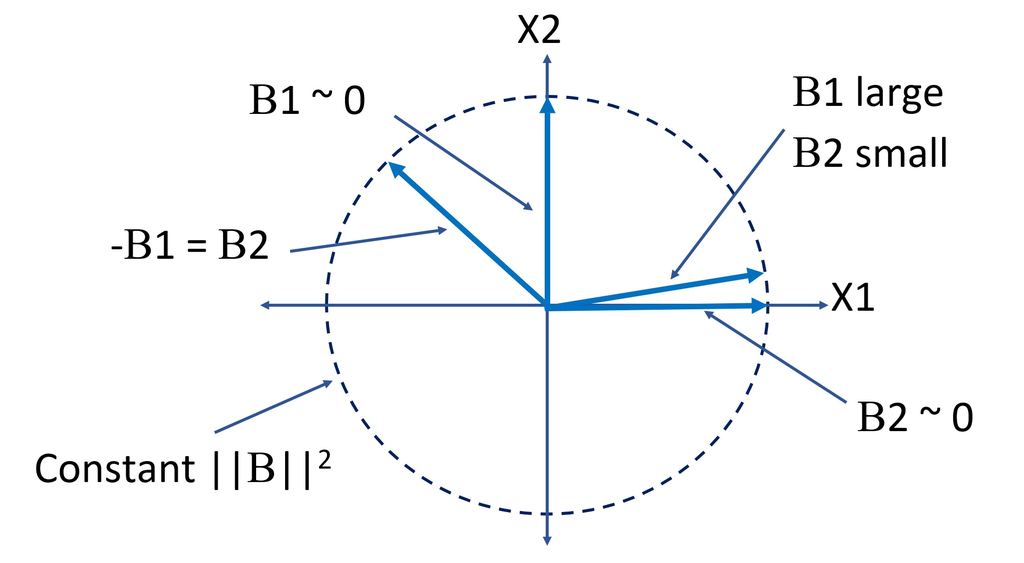

L2 norm constraint of model coefficients

- Notice that L2 regularization is a **soft constraint** on parameter values

# L2 Regularization

Example: Increasing constraint on model coefficients with larger L2 regularization hyperparameter

```python
def regularized_coefs(df_train, df_test, alphas, L1_wt=0.0, n_coefs=8,
                      formula = 'socst_zero_mean ~ C(ses)*C(prog)',
                      label='socst_zero_mean'):
    '''Function that computes a linear model for each value of the regularization
    parameter alpha and returns an array of the coefficient values. The L1_wt
    determines the trade-off between L1 and L2 regularization'''
    coefs = np.zeros((len(alphas),n_coefs + 1))
    MSE_train = []
    MSE_test = []
    for i,alpha in enumerate(alphas):
        ## First compute the training MSE
        temp_mod = smf.ols(formula, data=df_train).fit_regularized(alpha=alpha,L1_wt=L1_wt)
        coefs[i,:] = temp_mod.params
        MSE_train.append(np.mean(np.square(df_train[label] - temp_mod.predict(df_train))))
        ## Then compute the test MSE
        MSE_test.append(np.mean(np.square(df_test[label] - temp_mod.predict(df_test))))

    return coefs, MSE_train, MSE_test

alphas = np.arange(0.0, 0.3, step = 0.003)
Betas, MSE_test, MSE_train = regularized_coefs(test_scores_train, test_scores_test, alphas)
```

# L2 Regularization

Example: Increasing constraint on model coefficients with larger L2 regularization hyperparameter

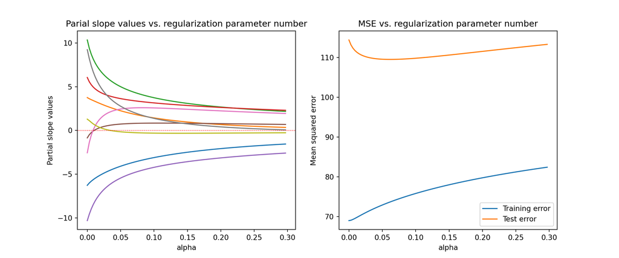

# L1 Regularization

The L1 norm provides regularization with different properties

- Constrains the model parameters using the L1 norm:

$$min [\parallel A \cdot x - b \parallel
+\ \alpha^2 \parallel b\parallel^1]$$

- This form looks a lot like the L2 regularization formulation
- $\parallel b\parallel^1$ is the L1 norm
- Compute the L1 norm of the $p$ model parameters:

$$||b||^1 = \big( |\beta_0| + |\beta_1| +
\ldots + |\beta_p| \big) = \Big( \sum_{i=0}^m |\beta_i|
\Big)^1$$

$|\beta_i|$ is the absolute value of $\beta_i$.

# L1 Regularization

What are the properties of the L1 regularization

- L1 norm is a **hard constraint**
- L1 regularization drives coefficients to zero
- The hard constraint property leads to the term **lasso regularization**
- Lasso regression is a method of **feature selection**

# L1 Regularization

The Lasso regularization is a strong constraint on coefficient values

- Some coefficients are forced to zero
- The constraint curve is like a *lasso*

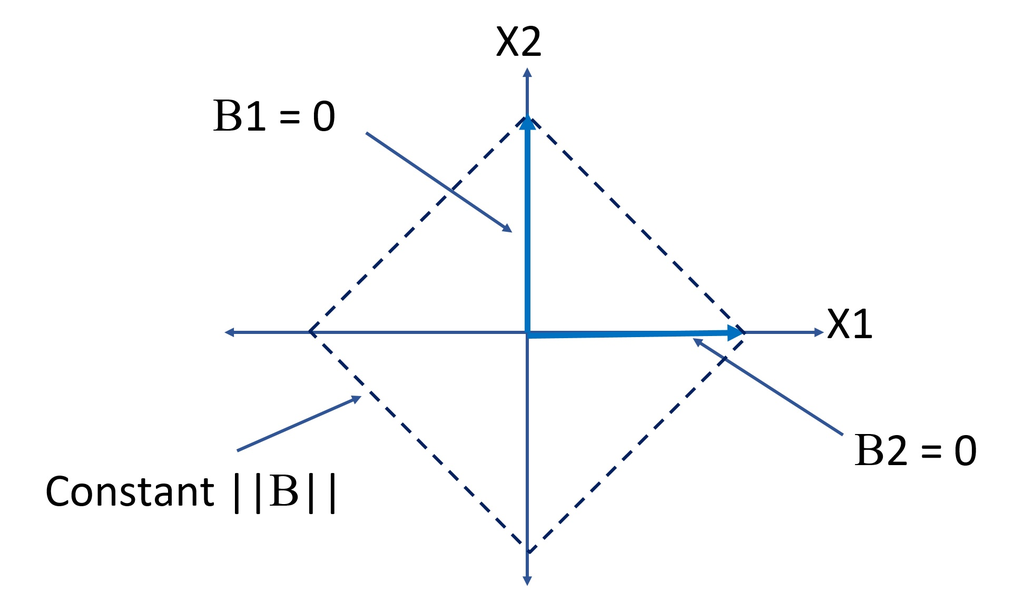

L1 norm constraint of model coefficients

# L1 Regularization

Example: Increasing constraint on model coefficients with larger L1 regularization hyperparameter

```python
alphas = np.arange(0.0, 0.6, step = 0.02)
Betas, MSE_train, MSE_test = regularized_coefs(test_scores_train, test_scores_test, alphas, L1_wt=1.0) #, formula=formula)
Betas[:5]
```

```
## array([[ -6.13412699,   3.62867936,  10.20615579,   5.88403028,
##         -10.44293454,  -0.68215407,  -2.3846305 ,   9.37695361,
##           1.44233432],
##        [ -5.72441839,   3.43435166,   8.75855958,   4.84586199,
##          -9.40956564,   0.05313331,   0.        ,   7.99487046,
##           0.        ],
##        [ -5.55039369,   3.33123726,   8.51053097,   4.79924961,
##          -9.03159592,   0.        ,   0.        ,   7.41265712,
##           0.        ],
##        [ -5.35379746,   3.19004869,   8.26727483,   4.72128125,
##          -8.68047004,   0.        ,   0.        ,   6.87279024,
##           0.        ],
##        [ -5.15720816,   3.04893453,   8.02408465,   4.64326246,
##          -8.32934311,   0.        ,   0.        ,   6.33285484,
##           0.        ]])
```

# L1 Regularization

Example: Increasing constraint on model coefficients with larger L1 regularization hyperparameter

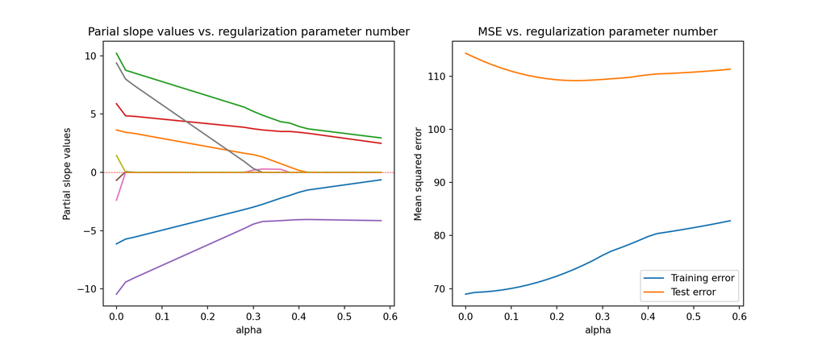

# Elastic Net Regularization

Do we always have to choose between the soft constraint of L2 and the hard constraint of L1?

- L2 regularization works well for **colinear features** as soft constraint
  - Down-weights colinear features
  - But soft constraint so poor model selection
- L1 regularization provides **good model selection** as hard constraint
  - Drives coefficients of non-informative variables to 0
  - But poor selection for colinear features
- The **Elastic Net** weights L1 and L2 regularization
  - Hyperparameter $\lambda$ weights L1 vs. L2 regularization
  - Hyperparameter $\alpha$ sets strength of regularization

$$min \Big[ \parallel A \cdot x - b
\parallel +\ \lambda\ \alpha \parallel b\parallel^1 +\ (1- \lambda)\
\alpha \parallel b\parallel^2 \Big]$$

# Elastic Net Regularization

Example: Increasing constraint on model coefficients with larger L1 regularization hyperparameter

```python
alphas = np.arange(0.0, 0.5, step = 0.02)
Betas, MSE_train, MSE_test = regularized_coefs(test_scores_train, test_scores_test, alphas, L1_wt=0.5)
```

# Elastic Net Regularization

Example: Increasing constraint on model coefficients with larger L1 regularization hyperparameter

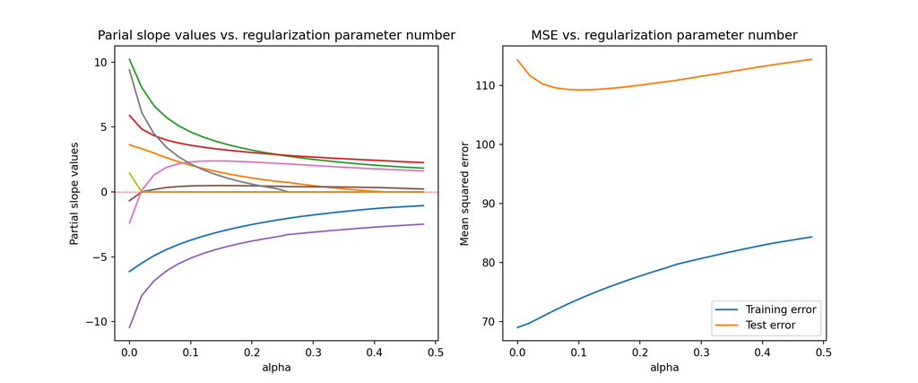

# Elastic Net Regularization

Check the model summary for $\lambda=0.5$, $\alpha=0.10$

```python
lm_elastic = smf.ols("socst_zero_mean ~ C(ses)*C(prog)", data=test_scores_train).fit_regularized(alpha=0.1, L1_wt=0.5)
lm_elastic.params
```

```
## Intercept                  -3.715924
## C(ses)[T.2]                 2.048593
## C(ses)[T.3]                 4.615190
## C(prog)[T.2]                3.589684
## C(prog)[T.3]               -5.103465
## C(ses)[T.2]:C(prog)[T.2]    0.455652
## C(ses)[T.3]:C(prog)[T.2]    2.310118
## C(ses)[T.2]:C(prog)[T.3]    2.149526
## C(ses)[T.3]:C(prog)[T.3]    0.000000
## dtype: float64
```

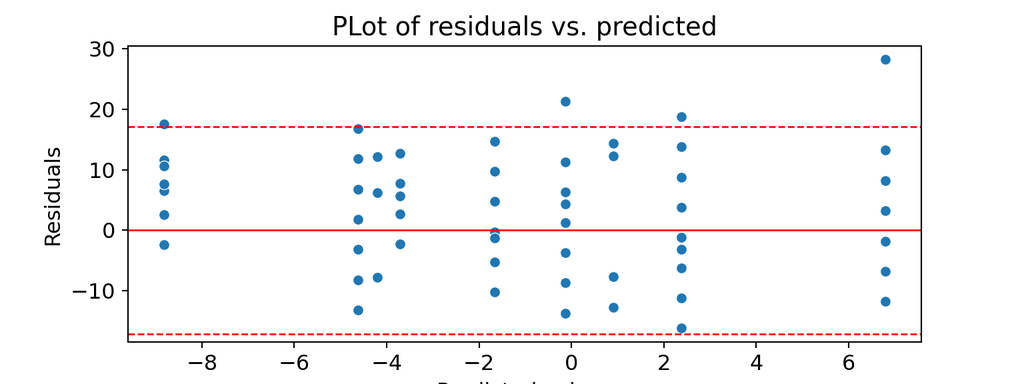

# Summary

Over-fit models and regularization

- **Bias variance trade-off** between fit to training data (bias) and generalization error (vaiance)
- Prefer minimal or **sparse models**
- L2 regularization is a soft constraint
- L1 regularization is a hard constraint
- ElasticNet trade-off between L1 and L2